# R Notebook

Here we retrieve the data from mongo.

```r
library(mongolite)
library(e1071)
library(FNN)
my_collection <- mongo(collection = "seasons", db = "DS4100Project") # create connection, database and collection
data <- my_collection$find()
```

Here I create the training and validation datasets

```r
training_size <- ceiling(nrow(data) * .7)
indices <- 1:nrow(data)
set.seed(33)
training_indices <- sample(indices, size=training_size)
training_data <- data[training_indices,]
validation_indices <- setdiff(indices, training_indices)
validation_data <- data[validation_indices,]
```

At first I started with all features. Then in order I used backwards elim to remove:

“LAL”, “ATL”, “DRB”, “WAS”, “SDC”, “DET”, “PTS”, “NOH”, “WS”, “FG”, “C”, “TOV_”, “TOR”, “OWS”, “TS_”, “X3P_”, “GS”, “CHH”, “AST”, “PG”, “BOS”, “NYK”, “USG_”, “KCK”, “FT_”, “FT”, “FGA”, “DWS”, “BRK”, “Year”, “TRB”, “NOK”, “VAN”, “LAC”, “POR”, “HOU”, “MIL”, “NOP”, “PHO”, “MIN”, “DEN”, “UTA”, “PHI”, “TOT”, “IND”, “SAC”, “SEA”, “GSW”, “WSB”, “ORL”, “MEM”, “X2P_”, “X3PA”, “eFG_”, “OKC”, “X2PA”, “X3P”, “CHI”, “BLK”, “MIA”, “ORB_”, “DRB_”, “NJN”, “DBPM”, “SAS”, “CLE”

```r
remove_from_lm <- c("X_1", "X", "Player", "NextSeasonChange",
                    "LAL", "ATL", "DRB", "WAS", "SDC", "DET", "PTS", "NOH", "WS",
                    "FG", "C", "TOV_", "TOR", "OWS", "TS_", "X3P_", "GS", "CHH", "AST", "PG",
                    "BOS", "NYK", "USG_", "KCK", "FT_", "FT", "FGA", "DWS", "BRK", "Year",
                    "TRB", "NOK", "VAN", "LAC", "POR", "HOU", "MIL", "NOP", "PHO", "MIN", "DEN",
                    "UTA", "PHI", "TOT", "IND", "SAC", "SEA", "GSW", "WSB", "ORL", "MEM", "X2P_",
                    "X3PA", "eFG_", "OKC", "X2PA", "X3P", "CHI", "BLK", "MIA", "ORB_", "DRB_",
                    "NJN", "DBPM", "SAS", "CLE")
features <- colnames(training_data)
features <- features[! features %in% remove_from_lm]
fmla <- as.formula(paste("NextSeasonChange ~ ", paste(features, collapse= "+")))
mod <- lm(fmla, training_data)
summary(mod)
```

```
Call:
lm(formula = fmla, data = training_data)

Residuals:
     Min       1Q   Median       3Q      Max
-1.16694 -0.17673 -0.00861  0.15809  2.20444

Coefficients:
              Estimate Std. Error t value Pr(>|t|)
(Intercept)  1.6970887  0.1322154  12.836  < 2e-16 ***
Age         -0.0289915  0.0015905 -18.228  < 2e-16 ***
G           -0.0029940  0.0005597  -5.349 9.38e-08 ***
MP          -0.0093700  0.0020491  -4.573 4.97e-06 ***
PER         -0.0587431  0.0086174  -6.817 1.08e-11 ***
FTr          0.4921797  0.1024973   4.802 1.63e-06 ***
TRB_         2.5013839  0.4685106   5.339 9.91e-08 ***
AST_         0.4124172  0.1389564   2.968 0.003017 **
STL_        19.3800533  3.0128041   6.433 1.42e-10 ***
BLK_         3.6665272  0.9604148   3.818 0.000137 ***
WS_48        2.6761485  0.3743488   7.149 1.05e-12 ***
OBPM         0.0512289  0.0124306   4.121 3.85e-05 ***
BPM         -0.0478834  0.0108176  -4.426 9.86e-06 ***
VORP         0.0558053  0.0117218   4.761 2.00e-06 ***
FG_         -1.1713247  0.2116833  -5.533 3.36e-08 ***
X2P          0.0713660  0.0091968   7.760 1.09e-14 ***
FTA         -0.0377080  0.0121074  -3.114 0.001857 **
ORB         -0.0449692  0.0148175  -3.035 0.002423 **
STL         -0.2657671  0.0461736  -5.756 9.33e-09 ***
TOV          0.0488822  0.0190444   2.567 0.010305 *
PF          -0.0625838  0.0122948  -5.090 3.75e-07 ***
Improvement -0.0891736  0.0139350  -6.399 1.76e-10 ***
SG           0.0525550  0.0165348   3.178 0.001493 **
SF           0.0337751  0.0159904   2.112 0.034736 *
DAL          0.0739202  0.0296104   2.496 0.012588 *
CHA         -0.1439576  0.0669358  -2.151 0.031566 *
---
Signif. codes:  0 ‘***’ 0.001 ‘**’ 0.01 ‘*’ 0.05 ‘.’ 0.1 ‘ ’ 1

Residual standard error: 0.3171 on 3688 degrees of freedom
Multiple R-squared:  0.2329,    Adjusted R-squared:  0.2277
F-statistic: 44.79 on 25 and 3688 DF,  p-value: < 2.2e-16
```

Here is further proof that the model did not perform well. I was unable to find features that could provide for a somewhat accurate prediction. The graph below shows the inaccuracy of the model, if the data mostly fell on the y=x line then we would know that it were much more accurate

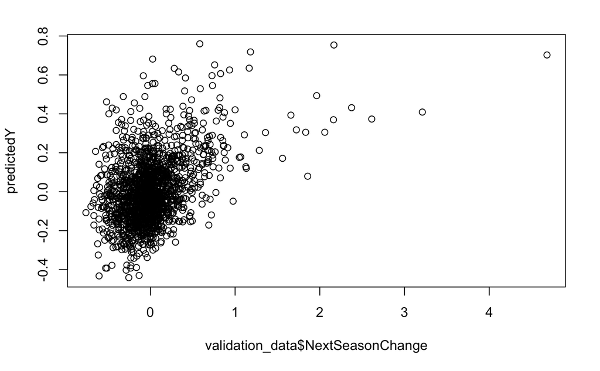

```r
# make a prediction for each X
predictedY <- predict(mod, validation_data)
# display the predictions
plot(validation_data$NextSeasonChange, predictedY)
```